# Supplemental Materials

### 3.1.3 Compositional RDA plots

#### Explained Variance in RDA’s

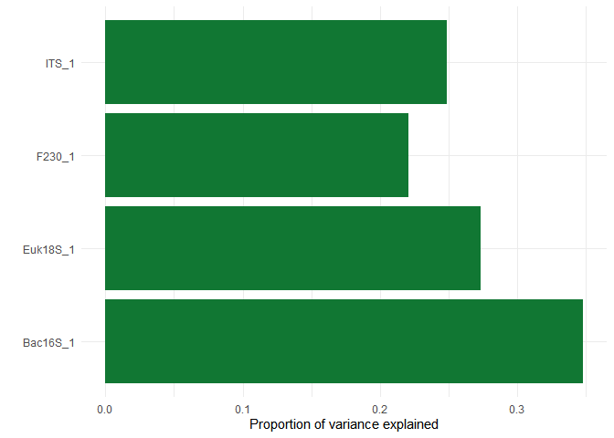

Figure 3.6: Proportion of community structural variance explained by harvesting treatment. Model names are described as the targeted gene (16S, 18S, ITS, or, F230), summarization level (ESV, genus, or functional groupings) and the soil layers represented in the rda model (MIN = 0-10 cm depth mineral soil samples, LFH = L, FH, or LFH samples).

#### Bacterial (16S)

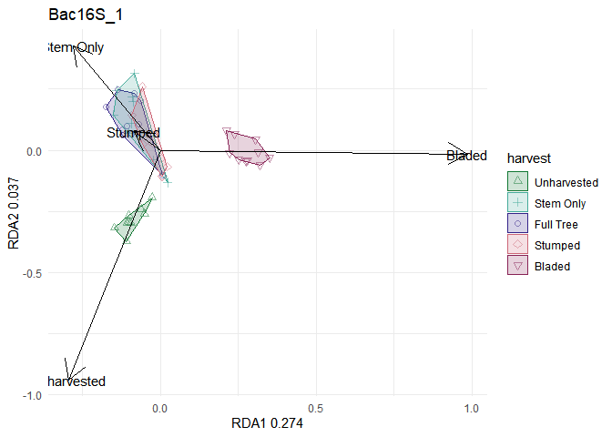

#### Fungal (ITS)

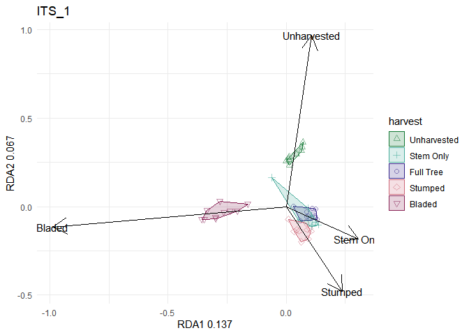

#### Arthropods (F230)

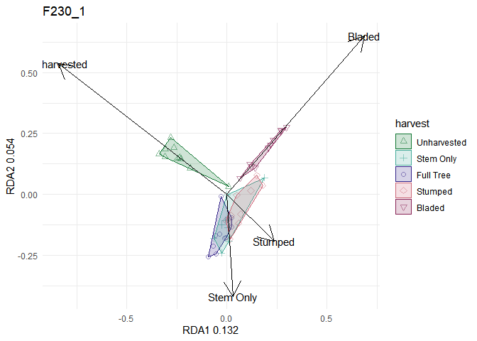

#### Eukaryotes (18S)

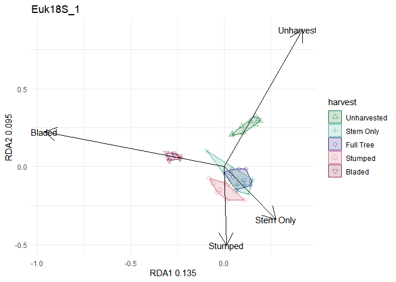

The RDA axes associated with Unharvested and Bladed treatments explained more variance (0.132 - 0.274) than other axes, these differences were confirmed by the significantly different compositions of Bladed and Unharvested treatments from Full-tree harvesting found in PERMANOVA. The remaining RDA axes associated with Stumped and Stem Only treatments explained smaller amounts of variance (0.037 - 0.095). Stumped treatments were significantly different from full-tree harvesting, but there was no significant difference between stem only and full tree harvesting.

### 3.1.4 Differences in specific organisms

#### Bac16S

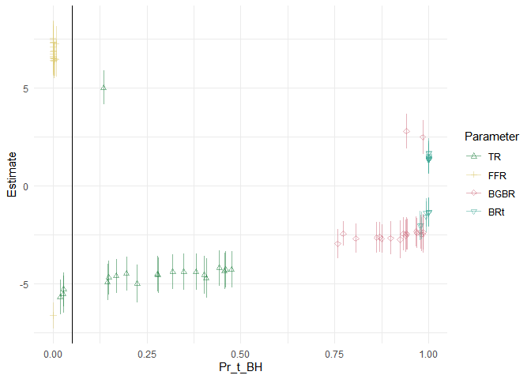

Graph shows 20 most significant organisms for each parameter.

[figure not shown]

#### ITS

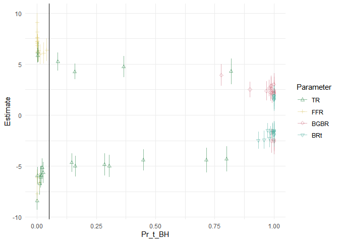

Graph shows 20 most significant organisms for each parameter.

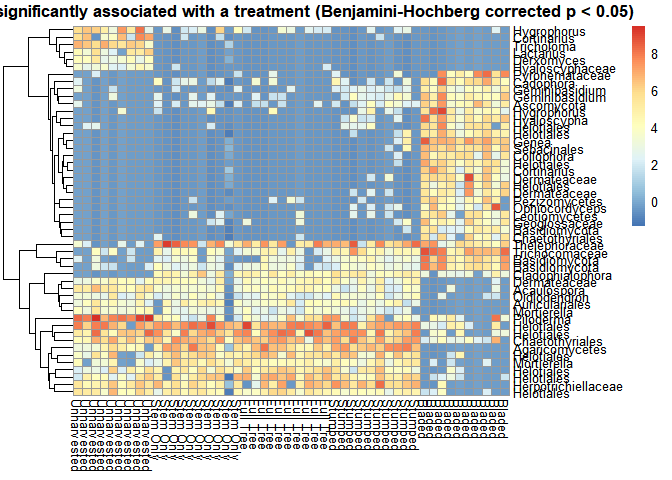

#### F230

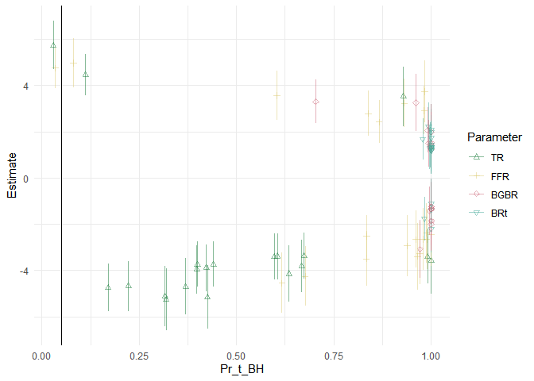

Graph shows 20 most significant organisms for each parameter.

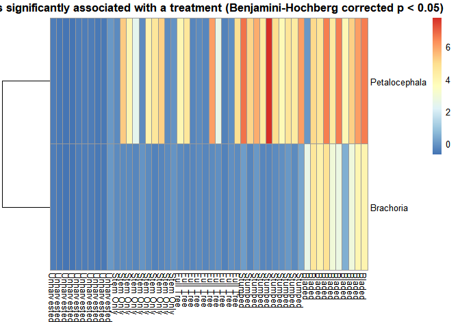